# Naive Bayes für Spam-Klassifizierung aus Packt Machine Learning with R

Jonathan Schuster Kontakt: schuster.jonathan95@gmail.com

11/28/2021

# Setup

## Libraries:

- tm - zum Erstellen und Bereinigen von Korpus und Dokumenten-Term-Matrix
- SnowballC - für Stemming
- wordcloud - zum Erstellen von Wordclouds
- e1071 - zum Erstellen des Modells
- gmodels - zum Auswerten des Modells per Kreuztabelle

```r
library(tm)
```

```r
library(SnowballC)
library(wordcloud)
library(e1071)
library(gmodels)
```

## Datensatz laden

Wir verwenden den sms_spam Datensatz, der auf https://github.com/PacktPublishing/Machine-Learning-with-R-Third-Edition in Chapter 04 gefunden weren kann. Die Spalte *type*, in der Nachrichten entweder *spam* oder *ham* zugeordnet sind konvertieren wir als Faktor.

```r
sms_raw <- read.csv("sms_spam.csv", stringsAsFactors = FALSE)

sms_raw$type <- factor(sms_raw$type)
```

## Korpus erstellen

Anschließend können wir über die Funktionen *VCorpus()* und *VectorSource()* einen Korpus aus den Texten erstellen. Über die Funktionen *lapply()* und *as.character()* können wir uns dann die ersten beiden Einträge anschauen:

```r
sms_corpus <- VCorpus(VectorSource(sms_raw$text))

lapply(sms_corpus[1:2], as.character)
```

```
## $`1`
## [1] "Hope you are having a good week. Just checking in"
##
## $`2`
## [1] "K..give back my thanks."
```

# Datenbereinigung

Nun muss der Korpus bereinigt werden. Dazu verwenden wir die Funktionen *content_transformer()* und *tolower()*, um alle großen zu kleinen Buchstaben zu transformieren, die Funktionen *removeNumbers()*, um alle Nummern zu entfernen, *removeWords()* und *stopwords()* um inhaltslose Worte zu entfernen und *removePunctuation()* um Satzzeichen zu löschen.

```r
sms_corpus_clean <- tm_map(sms_corpus, content_transformer(tolower))
sms_corpus_clean <- tm_map(sms_corpus_clean, removeNumbers)
sms_corpus_clean <- tm_map(sms_corpus_clean, removeWords, stopwords())
sms_corpus_clean <- tm_map(sms_corpus_clean, removePunctuation)
```

Ein alternativer Ansatz zur Bereinigung von Satzzeichen, indem diese nicht einfach nur entfernt, sondern durch Leerzeichen ersetzt werden, wäre mit folgendem Code möglich:

```r
replacePunctuation <- function(x) {gsub("[[:punct:]]+", " ", x)}
```

Nun können wir sogenanntes “Stemming” anwenden, um verschiedene Ausführungen von Worten mit der selben Bedeutung zusammenzufassen.

```r
sms_corpus_clean <- tm_map(sms_corpus_clean, stemDocument)
sms_corpus_clean <- tm_map(sms_corpus_clean, stripWhitespace)
```

# Dokumenten-Term-Matrix

Nun können wir aus unserem Korpus eine Dokumenten-Term-Matrix erstellen, in der für jedes Dokument (Zeilen) festgehalten wird, wie oft welche Worte (Spalten) in dem jeweiligen Dokument vorkommen:

```r
sms_dtm <- DocumentTermMatrix(sms_corpus_clean)
```

Es wäre an dieser Stelle auch möglich gewesen, die Bereinigung innerhalb der Funktion *DocumentTermMatrix()* vorzunehmen, dabei ist jedoch zu beachten, dass dies eventuell zu anderen Ergebnissen führt, da die Reihenfolge der Bereinigungsschritte von unserer abweicht:

```r
# Alternative:
sms_dtm2 <- DocumentTermMatrix(sms_corpus, control = list(
  tolower = TRUE,
  removeNumbers = TRUE,
  stopwords = TRUE,
  removePunctuation = TRUE,
  stemming = TRUE
))
```

Eine weitere Alternative, die zu unserem Ergebnis führt, kann durch Ersetzen der stopwords-Funktion angewendet werden:

```r
# Alternative 2:
sms_dtm3 <- DocumentTermMatrix(sms_corpus, control = list(
  tolower = TRUE,
  removeNumbers = TRUE,
  stopwords = function(x) { removeWords(x, stopwords())},
  removePunctuation = TRUE,
  stemming = TRUE
))
```

Je nach Anwendungsfall, kann eine dieser Möglichkeiten einer anderen vorgezogen werden. Es ist jedoch immer zu beachten, in welcher Reihenfolge die einzelnen Bereinigungsschritte durchgeführt werden, da Ergebnisse je nach Reihenfolge stark voneinander abweichen können.

## Wordcloud

Um uns anzuschauen, ob starke Unterschiede in den Texten der spam und ham Nachrichten vorkommen, können wir uns vorab schon einmal eine Wordcloud anschauen.  
Dafür müssen wir lediglich unseren rohen Datensatz über die Funktion *subset()* aufteilen und können dann unsere Wordcloud erstellen.

```r
spam <- subset(sms_raw, type == "spam")
ham <- subset(sms_raw, type == "ham")
```

So sieht unsere Wordcloud für spam-Nachrichten aus:

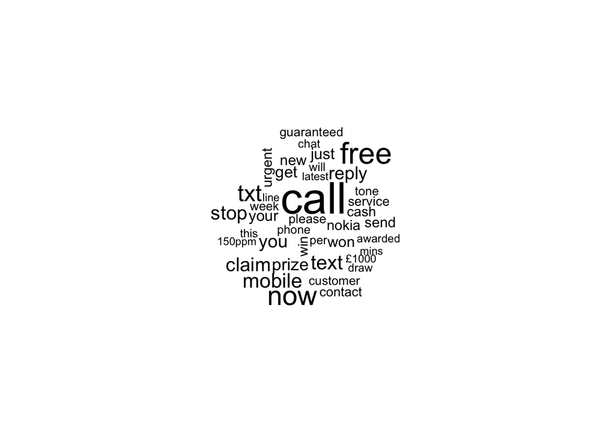

```r
wordcloud(spam$text, max.words = 40, scale = c(3, 0.5))
```

Und so unsere Wordcloud für ham-Nachrichten:

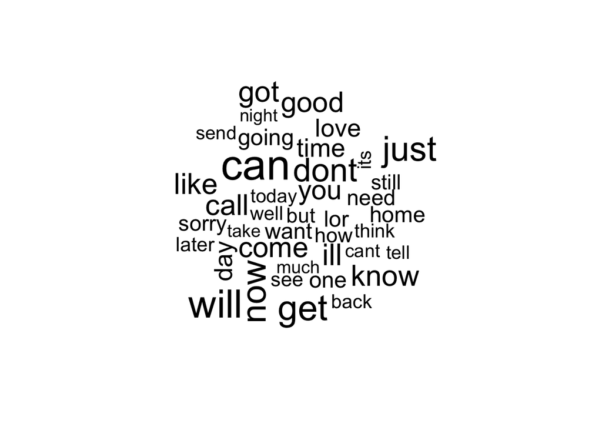

```r
wordcloud(ham$text, max.words = 40, scale = c(3, 0.5))
```

# Naive Bayes

## Aufteilung in Train/Test Daten

Nun können wir den Datensatz aufteilen. Dazu nehmen wir 75% der Daten für das Training und 25% für das Testen. Teilen können wir unsere Dokument-Term-Matrix ganz einfach über die [rows, columns] Festlegung. Anschließend müssen wir noch aus unserem *sms_raw* Datensatz über *$type* die Labels, also unsere Zuordnungen zu ham und spam ziehen und zwei Vektoren hinzufügen.

Durch *prop.table* können wir anschließend vergleichen, wieviele Einträge aus unseren zwei Klasen in den Trainings- und Testdatensätzen vorkommen. Da unser Datensatz von Anfang an zufällig durchmischt war, finden wir in beiden Datensätzen in etwa 13% spam-Nachrichten. Die Datensätze sind also wie gewünscht sehr ausgeglichen.

```r
sms_dtm_train <- sms_dtm[1:4169, ]
sms_dtm_test <- sms_dtm[4170:5559, ]

sms_train_labels <- sms_raw[1:4169, ]$type
sms_test_labels <- sms_raw[4170:5559, ]$type

prop.table(table(sms_train_labels))
```

```
## sms_train_labels
##       ham      spam
## 0.8647158 0.1352842
```

```r
prop.table(table(sms_test_labels))
```

```
## sms_test_labels
##       ham      spam
## 0.8683453 0.1316547
```

## Modellierung

Um unser Modell erstellen zu können, müssen wir nurnoch ein paar letzte Vorbereitungen durchführen. Zunächst möchten wir alle Worte, die in weniger als 5 Dokumenten vorkommen aus unserer Matrix entfernen. Über die Funktion *findFreqTerms* können wir uns eine Liste erstellen lassen, in denen alle Worte, die in mindestens 5 Dokumenten vorkommen festzuhalten. Anschließend können wir zwei neue Dokumenten-Term-Matrizen erstellen, die nurnoch die Spalten und damit Worte enthalten, die in unserer Liste vorkommen:

```r
sms_freq_words <- findFreqTerms(sms_dtm_train, 5)
sms_dtm_freq_train <- sms_dtm_train[ , sms_freq_words]
sms_dtm_freq_test <- sms_dtm_test[ , sms_freq_words]
```

Da der Naive Bayes Algorithmus mit kategorialen Variablen arbeitet, müssen wir nun noch die Zahlen in unseren Matrizen ersetzen. Dazu definieren wir zuerst die Funktion *convert_counts()*, durch die wir alle Zahlen größer als 0 in unserer Matrix durch “Yes” und alle anderen durch “No” ersetzen.  
Anschließend können wir unsere Funktion *convert_counts* mit *apply()* und dem Parameter *MARGIN = 2* für unsere Spalten anwenden.

```r
convert_counts <- function(x) {
  x <- ifelse(x > 0, "Yes", "No")
}

sms_train <- apply(sms_dtm_freq_train, MARGIN = 2, convert_counts)
sms_test <- apply(sms_dtm_freq_test, MARGIN = 2, convert_counts)
```

Jetzt können wir mit der Funktion *naiveBayes* unser Modell, also unseren Klassifizierer erstellen und über *predict()* auf unseren Testdatensatz anwenden.

```r
sms_classifier <- naiveBayes(sms_train, sms_train_labels)
sms_test_pred <- predict(sms_classifier, sms_test)
```

Das Ergebnis ist dann eine Liste mit den Vorhersagen für unseren Testdatensatz, den wir wie folgt in einer Kreuztabelle mit den wirklichen Ergebnissen (spam oder ham) vergleichen können:

```r
CrossTable(sms_test_pred, sms_test_labels,
           prop.chisq = FALSE, prop.c = FALSE, prop.r = FALSE,
           dnn = c('predicted', 'actual'))
```

```
##
##
##    Cell Contents
## |-------------------------|
## |                       N |
## |         N / Table Total |
## |-------------------------|
##
##
## Total Observations in Table:  1390
##
##
##              | actual
##    predicted |       ham |      spam | Row Total |
## -------------|-----------|-----------|-----------|
##          ham |      1201 |        30 |      1231 |
##              |     0.864 |     0.022 |           |
## -------------|-----------|-----------|-----------|
##         spam |         6 |       153 |       159 |
##              |     0.004 |     0.110 |           |
## -------------|-----------|-----------|-----------|
## Column Total |      1207 |       183 |      1390 |
## -------------|-----------|-----------|-----------|
##
##
```

Dabei stellen wir fest, dass unser Modell bei 1201+153=**1354 von 1390** Fällen richtig lag und nur 6+30=**36 von 1390** Fälle falsch zugeordnet hat. 97,41% der Vorhersagen waren richtig.

Dennoch sehen wir auch, dass in 6 Fällen echte Nachrichten für spam gehalten wurden. Nutzer unseres Spamfilters könnten dadurch wichtige Nachrichten übersehen. Es besteht also noch Optimierungsbedarf.

Eine Möglichkeit den Naive Bayes Algorithmus zu optimieren, bietet die Verwendung der sogenannten Laplace-Glättung. Der Kern des naive Bayes Algorithmus besteht darin, jedem Wort über eine Likelihood-Tabelle einer Wahrscheinlichkeit zuzuordnen, nach der dieses Wort auftritt. Haben wir jedoch in unserem Test-Datensatz Worte, die im Trainings-Datensatz nicht vorkommen, wäre die Wahrscheinlichkeit für diese Worte gleich 0. Um dieses Problem zu umgehen, kann jedem Wort ein Grundwert zugeordnet werden. Diesen können wir wie folgt über *laplace = 1* festsetzen:

```r
sms_classifier2 <- naiveBayes(sms_train, sms_train_labels, laplace = 1)
sms_test_pred2 <- predict(sms_classifier2, sms_test)

CrossTable(sms_test_pred2, sms_test_labels,
           prop.chisq = FALSE, prop.c = FALSE, prop.r = FALSE,
           dnn = c('predicted', 'actual'))
```

```
##
##
##    Cell Contents
## |-------------------------|
## |                       N |
## |         N / Table Total |
## |-------------------------|
##
##
## Total Observations in Table:  1390
##
##
##              | actual
##    predicted |       ham |      spam | Row Total |
## -------------|-----------|-----------|-----------|
##          ham |      1189 |        16 |      1205 |
##              |     0.855 |     0.012 |           |
## -------------|-----------|-----------|-----------|
##         spam |        18 |       167 |       185 |
##              |     0.013 |     0.120 |           |
## -------------|-----------|-----------|-----------|
## Column Total |      1207 |       183 |      1390 |
## -------------|-----------|-----------|-----------|
##
##
```

In unserem Fall hat die Laplace-Glättung leider nur die Fehlerquote der für ham gehaltenen spam-Nachrichten verbessert (von 30 auf 16) und dabei unsere Fehlerquote der für spam gehaltenen ham-Nachrichten weiter verschlechtert (von 6 auf 18). Die Genauigkeit unserer Modelle ist dennoch äußerst hoch.

# Weitere Ressourcen

- [Packt Machine Leraning wiht R - Github](https://github.com/PacktPublishing/Machine-Learning-with-R-Third-Edition)
- [Hintergrund zur Laplace-Glättung](https://towardsdatascience.com/laplace-smoothing-in-na%C3%AFve-bayes-algorithm-9c237a8bdece)